# Algebra and Statistical Methods for Big Data with Bioconductor

Dolors Pelegri and Juan R. Gonzalez

Universitat de Barcelona - Universitat de Barcelona (UAB)  
ISGlobal, Centre for Research in Environmental Epidemiology (CREAL)  
Bioinformatics Research Group in Epidemiolgy (BRGE)

juanr.gonzalez@isglobal.org

2021-04-16

#### Abstract

Description of functions to perform matrix operations, algebra and some statistical models using *DelayedMatrix* objects and HDF5 data files.

#### Package

BigDataStatMeth 0.99.1

# 1 Prerequisites

The package requires other packages from `Bioconductor` and `R-Cran` to be installed. From `Bioconductor` we need to install `beachmat`, `HDF5Array`, `DelayedArray` and `rhdf5`. From `R-cran` we need to install the packages `Matrix`, `RcppEigen` and `RSpectra`.

# 2 Overview

This package implements seveal matrix operations using `DelayMatrix` objects and HDF5 data files as well as some basic algebra operations that can be used to carry out some statistical analyses using standard methodologies such as principal component analyses (PCA) or least squares estimation. The package also contains specific statatistical methods mainly used in `omic` data analysis such as lasso regression. All procedures referred to HDF5 can be found in [BigDataStatMeth_hdf5](https://github.com/isglobal-brge/BigDataStatMeth/blob/main/vignettes/BigDataStatMeth_hdf5.html) vignette

# 3 Getting started

First, let us start by loading the required packages to describe the main capabilities of the package

```r
library(BigDataStatMeth)
library(DelayedArray)
library(rhdf5)
library(DT)
```

To install BigDataStatMeth package we only have to run the following commands from the R command shell

```r
# Install devtools and load library (if not previously installed)
install.packages("devtools")
library(devtools)

# Install BigDataStatMeth and load package
install_github("isglobal-brge/BigDataStatMeth@HEAD")
library(BigDataStatMeth)
```

These other packages are required to reproduce this vignette

```r
library(microbenchmark)
```

# 4 Matrix Multiplication

In this section, different products of matrices and vectors are introduced. The methods implement different strategies including block multiplication algorithms and the use of parallel implementations.

## 4.1 Block matrix multiplication

$$A*B=\begin{pmatrix} { A }_{ 11 } & { A }_{ 12 } \\ { A }_{ 21 } & { A }_{ 22 } \end{pmatrix}*\begin{pmatrix} { B }_{ 11 } & B_{ 12 } \\ B_{ 21 } & B_{ 22 } \end{pmatrix}=\begin{pmatrix} { C }_{ 11 } & C_{ 12 } \\ C_{ 21 } & C_{ 22 } \end{pmatrix}=C$$

Let us simulate to set of matrices to illustrate the use of the function accross the entire documment. First, we simulate a simple case with to matrices A and B with dimensions 500x500 and 500x750, respectively. Second, another example with dimensions 1000x10000 are use to evaluate the performance in large matrices. The examples with big datasets will be illustrated using real data belonging to different omic settings. We can simulate to matrices with the desired dimensions by

```r
# Define small matrix A and B
set.seed(123456)
n <- 500
p <- 750
A <- matrix(rnorm(n*n), nrow=n, ncol=n)
B <- matrix(rnorm(n*p), nrow=n, ncol=p)


# Define big matrix Abig and Bbig
n <- 1000
p <- 10000
Abig <- matrix(rnorm(n*n), nrow=n, ncol=n)
Bbig <- matrix(rnorm(n*p), nrow=n, ncol=p)
```

They can be converted into `DelayedMatrix` object by simply

```r
DA <- DelayedArray(A)
DB <- DelayedArray(B)
```

Matrix multiplication using block matrices is implemented in the `blockmult()` function. It only requires to setting the argument `block_size`, by default `block_size = 128`. An optimal block size is important to better performance but it is difficult to asses what is the optimum block size for each matrix.

```r
# Use 10x10 blocks
AxB <- blockmult(A, B, block_size = 10)

# Use 256x256 blocks
AxBDelay <- blockmult(DA, DB, block_size = 256 )
```

As expected the results obtained using this procedure are the correct ones

```r
all.equal(AxBDelay,A%*%B)
[1] TRUE
all.equal(AxB, AxBDelay)
[1] TRUE
```

Note that when the argument `block_size` is larger than any of the dimensions of matrix A or B the `blocks_size` is set to `min(cols(A), rows(A), cols(B), rows(B))`.

The process can be speed up by making computations in parallel using `paral=TRUE` an optional parameter threads can be used to indicate the number of `threads` to launch simultaneously, if `threads=NULL` the function takes the available threads - 1, leaving one available for user.

```r
AxB <- blockmult(A, B, block_size = 10, paral = TRUE)
AxBDelay <- blockmult(DA, DB, block_size = 10, paral = TRUE )
AxBDelayT <- blockmult(DA, DB, block_size = 10, paral = TRUE, threads =  3 )

all.equal(AxBDelay,A%*%B)
[1] TRUE
all.equal(AxB, AxBDelay)
[1] TRUE
all.equal(AxBDelay, AxBDelayT)
[1] TRUE
```

To work with big matrices `blockmult()` can save matrices in hdf5 file format in order to be able to operate with them in blocks and not overload the memory, by default are considered large matrices if the number of rows or columns is greater than 5000, but it can be changed with `bigmatrix` argument. Or we can also force to execute the matrix multiplication with data on memory setting the parameter `onmemory = TRUE`

```r
DAbig <- DelayedArray(Abig)
DBbig <- DelayedArray(Abig)

# We want to force it to run in memory
AxBNOBig <- blockmult(Abig, Bbig, onmemory = TRUE)

# Run matrix multiplication with data on memory using submatrices of 256x256
AxBBig3000 <- blockmult(DAbig, DBbig, block_size = 256 ,  onmemory = TRUE)
```

Here, we compare the performace of the block method with the different options.

```r
bench1 <- microbenchmark(
  Paral128Mem = blockmult(Abig, Bbig, paral = TRUE), # Parallel block size = 128
  Paral256Disk = blockmult(Abig, Bbig, block_size=256, paral=TRUE), # On disk parallel block size = 256
  Paral256Mem = blockmult(Abig, Bbig, block_size=256, paral=TRUE, onmemory=TRUE),
  Paral1024Mem = blockmult(Abig, Bbig, block_size=1024, paral=TRUE, onmemory=TRUE),
  times = 3 )

bench1
Unit: seconds
         expr      min       lq     mean   median       uq       max neval
  Paral128Mem 9.115391 9.163770 9.474031 9.212149 9.653350 10.094552     3
 Paral256Disk 4.100724 4.122932 4.175566 4.145140 4.212987  4.280834     3
  Paral256Mem 1.150102 1.153384 1.155972 1.156666 1.158906  1.161146     3
 Paral1024Mem 1.651714 1.661215 1.669093 1.670717 1.677782  1.684848     3
```

We can observe that the shortest execution time is achieved with `block_size = 256`. The same information is depicted in the next Figure which illustrates the comparison between the different assessed methods

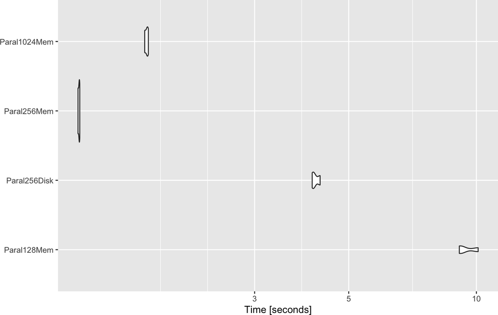

```r
ggplot2::autoplot(bench1)
```

## 4.2 Sparse matrix multiplication

A sparse matrix or sparse array is a matrix in which most of the elements are zero. `BigDataStatMeth` allows to perform matrix multiplication with sparse matrices using the function `blockmult_sparse`, It is necessary that at least one of the the matrices was defined as sparse in R, `dgCMatrix` class. An example of a sparse matrix could be :
$$\begin{equation}
\begin{bmatrix}
a_{11} & a_{12} & 0 & \cdots & \cdots & \cdots & \cdots & 0 \\
a_{21} & a_{22} & a_{23} & \ddots & && & \vdots \\
0 & a_{32} & a_{33} & a_{34} & \ddots & & & \vdots \\
\vdots & \ddots & \ddots & \ddots & \ddots & \ddots & & \vdots \\
\vdots & & \ddots & \ddots & \ddots & \ddots & \ddots& \vdots\\
\vdots & & & & \ddots & a_{n-1,n-2} & a_{n-1,n-1} & a_{n-1,n}\\
0 & \cdots & \cdots & \cdots & \cdots & 0 & a_{n,n-1} & a_{n,n} \\
\end{bmatrix}
\end{equation}$$

```r
k <- 1e3

# Generate 2 sparse matrix x_sparse and y_sparse
set.seed(1)
x_sparse <- sparseMatrix(
   i = sample(x = k, size = k),
   j = sample(x = k, size = k),
   x = rnorm(n = k)
)

set.seed(2)
y_sparse <- sparseMatrix(
   i = sample(x = k, size = k),
   j = sample(x = k, size = k),
   x = rnorm(n = k)
)

d <- blockmult_sparse(x_sparse, y_sparse)
f <- x_sparse%*%y_sparse

all.equal(d,f)
[1] TRUE
```

Here, we compare the performace using sparse matrix multiplication with sparse matrices and the blockmult multiplication with the same matrices not declared as sparce.

```r
res <- microbenchmark(
  sparse_mult = blockmult_sparse(x_sparse, y_sparse),
  matrix_mult = blockmult(as.matrix(x_sparse), as.matrix(y_sparse)),
  RSparse_mult = x_sparse%*% y_sparse,
  times = 3 )

res
Unit: microseconds
         expr        min         lq         mean     median          uq        max neval
  sparse_mult     50.297     51.510     65.33367     52.723     72.8520     92.981     3
  matrix_mult 108810.230 109078.879 109252.16667 109347.528 109473.1350 109598.742     3
 RSparse_mult    108.752    112.673    139.03100    116.594    154.1705    191.747     3
```

The same information is depicted in the next Figure which illustrates the comparison between the different assessed methods

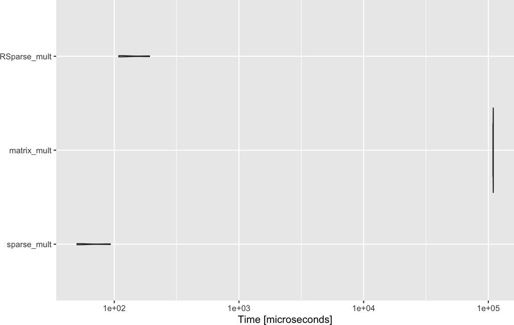

```r
ggplot2::autoplot(res)
```

We can observe the huge difference in execution time

# 5 Cross-product and Transposed Cross-product

To perform a cross-product and tcrossproduct with BigDataStatMeth we use the same function `bdcrossprod()` setting parameter `transposed` to TRUE or FALSE. Like other functions implemented in BigDataStatMeth, we can work with DelayedArray or R Objects. Setting parameter transposed for Crossproduct and tCrossProduct

- if `transposed = FALSE` (default), we perform a Crossproduct
  $$\left( C \right) ={ \left( A \right) }^{ t }\left( A \right)$$
- if `transposed = TRUE` : we perform a transposed-Crossproduct
  $$\left( C \right) = \left( A \right){ \left( A \right) }^{ t }$$

Here we shown some examples using `bdcrossprod` function

```r
n <- 500
m <- 250
A <- matrix(rnorm(n*m), nrow=n, ncol=m)
DA <- DelayedArray(A)

# Cross Product of a standard R matrix
cpA <- bdcrossprod(A)
# Result with DelayedArray data type
cpDA <- bdcrossprod(DA)
```

We obtain the expected values computed using `crossprod` R function

```r
all.equal(cpDA, crossprod(A))
[1] TRUE
```

you may also set `transposed=TRUE`

```r
# Transposed Cross Product R matrices
tcpA <- bdcrossprod(A, transposed = TRUE)
# With DelayeArray data types
tcpDA <- bdcrossprod(DA, transposed = TRUE)
```

We obtain the expected values computed using `tcrossprod` function

```r
all.equal(tcpDA, tcrossprod(A))
[1] TRUE
```

We can show that the implemented version really improves the R implementation computational speed.

```r
res <- microbenchmark(
  bdcrossp_tr = bdcrossprod(A, transposed=TRUE),
  rcrossp_tr = tcrossprod(A),
  bdcrossp = bdcrossprod(A),
  rcrossp = crossprod(A),
  times = 3)
res
Unit: milliseconds
        expr       min        lq      mean    median        uq       max neval
 bdcrossp_tr  6.998092  7.101065  7.719715  7.204039  8.080526  8.957013     3
  rcrossp_tr 21.844507 22.015973 22.295186 22.187438 22.520525 22.853613     3
    bdcrossp  3.133077  3.244745  3.290957  3.356413  3.369897  3.383382     3
     rcrossp 18.716493 18.723204 18.731880 18.729915 18.739573 18.749232     3
```

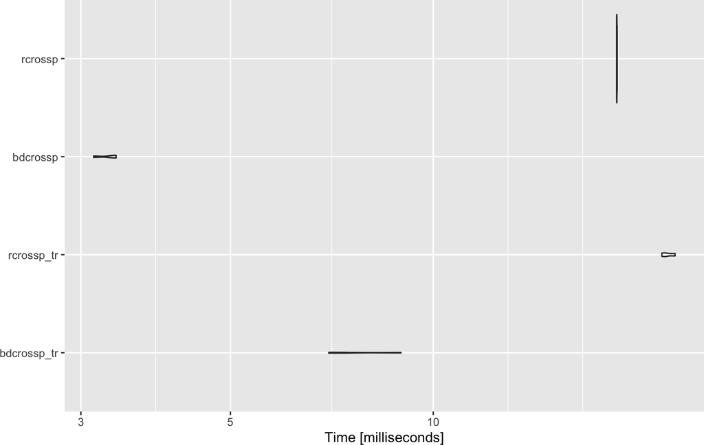

```r
ggplot2::autoplot(res)
```

# 6 Matrix Vector Multiplication

## 6.1 Weighted Cross-product and Weighted Transposed Cross-product

```r
n <- 250
X <- matrix(rnorm(n*n), nrow=n, ncol=n)
u <- runif(n)
w <- u * (1 - u)
DX <- DelayedArray(X)
Dw <- DelayedArray(as.matrix(w))

wcpX <- bdwproduct(X, w,"xwxt")
wcpDX <- bdwproduct(DX, Dw,"xwxt") # with DelayedArray

wcpDX[1:5,1:5]
           [,1]       [,2]       [,3]       [,4]      [,5]
[1,] 41.8137240  4.0688017 -3.5551601 -0.9590417 -3.649829
[2,]  4.0688017 35.8957169  0.4522855 -3.6490462  3.866538
[3,] -3.5551601  0.4522855 44.5225035  2.3956115  5.998364
[4,] -0.9590417 -3.6490462  2.3956115 36.3507446 -2.287474
[5,] -3.6498289  3.8665378  5.9983636 -2.2874736 42.947037
```

Those are the expected values as it is indicated by executing:

```r
all.equal( wcpDX, X%*%diag(w)%*%t(X) )
[1] TRUE
```

## 6.2 Weighted Transposed Cross Product

```r
wtcpX <- bdwproduct(X, w,"xtwx")
wtcpDX <- bdwproduct(DX, Dw,"xtwx") # with DelayedArray

wtcpDX[1:5,1:5]
          [,1]        [,2]      [,3]        [,4]      [,5]
[1,] 44.319669  4.02108694 -3.006229 -1.85345133 -3.786994
[2,]  4.021087 38.82933816 -3.638959 -0.03011039 -3.451078
[3,] -3.006229 -3.63895884 47.303628 -3.16577769  2.629315
[4,] -1.853451 -0.03011039 -3.165778 40.87522997  2.700950
[5,] -3.786994 -3.45107802  2.629315  2.70094954 41.088084
```

Those are the expected values as it is indicated by executing:

```r
all.equal(wtcpDX, t(X)%*%diag(w)%*%X)
[1] TRUE
```

# 7 Inverse Cholesky

The Cholesky factorization is widely used for solving a system of linear equations whose coefficient matrix is symmetric and positive definite.

$$A = LL^t = U^tU$$

where $L$ is a lower triangular matrix and U is an upper triangular matrix. To get the Inverse Cholesky we can use the function `bdInvCholesky()`. Let us start by illustrating how to do this computations in a simulated data:

```r
# Generate a positive definite matrix
Posdef <- function (n, ev = runif(n, 0, 10))
{
  Z <- matrix(ncol=n, rnorm(n^2))
  decomp <- qr(Z)
  Q <- qr.Q(decomp)
  R <- qr.R(decomp)
  d <- diag(R)
  ph <- d / abs(d)
  O <- Q %*% diag(ph)
  Z <- t(O) %*% diag(ev) %*% O
  return(Z)
}

A <- Posdef(n = 500, ev = 1:500)
DA <- DelayedArray(A)

invchol <- bdInvCholesky(A)
Dinvchol <- bdInvCholesky(DA)

round(invchol[1:5,1:5],8)
            [,1]        [,2]        [,3]        [,4]        [,5]
[1,]  0.01068322 -0.00063371 -0.00104697  0.00230612 -0.00173745
[2,] -0.00063371  0.00845418  0.00029448 -0.00104800  0.00020868
[3,] -0.00104697  0.00029448  0.00878553 -0.00074755  0.00006907
[4,]  0.00230612 -0.00104800 -0.00074755  0.02041952  0.00020405
[5,] -0.00173745  0.00020868  0.00006907  0.00020405  0.01137916
```

We can check whether this function returns the expected values obtained with the standard R function `solve`:

```r
all.equal(Dinvchol, solve(A))
[1] TRUE
```

We can show that the implemented version really improves the R implementation computational speed.

```r
res <- microbenchmark(invchol = bdInvCholesky(A),
                      invcholDelayedA = bdInvCholesky(DA),
                      invcholR = solve(A),
                      times = 3)
res
Unit: milliseconds
            expr      min       lq      mean   median        uq       max neval
         invchol 37.43791 38.99006  41.10160 40.54221  42.93345  45.32469     3
 invcholDelayedA 39.94762 41.42924  46.70262 42.91086  50.08013  57.24939     3
        invcholR 98.07282 98.49948 100.53024 98.92615 101.75894 104.59174     3
```

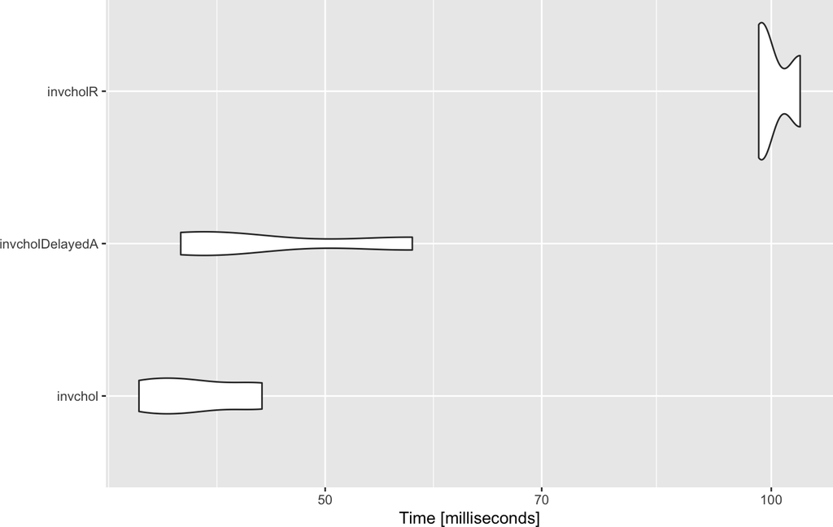

```r
ggplot2::autoplot(res)
```

# 8 Pseudo-Inverse

The Moore-Penrose pseudoinverse is a direct application of the SVD. The inverse of a matrix A can be used to solve the equation ${Ax}={b}$. But in the case where the set of equations have 0 or many solutions the inverse cannot be found and the equation cannot be solved. The following formula is used to find the pseudoinverse:
$${A}^+= {VD}^+{U}^T$$
In BigDataStatMeth we implemented Moore-Penrose pseudoinverse in function `bdpseudoinv`, now we get the pseudoinverse from a simulated data

```r
m <- 1300
n <- 1200

A <- matrix(rnorm(n*m), nrow=n, ncol=m)

pseudoinv <- bdpseudoinv(A)
zapsmall(pseudoinv)[1:5,1:5]
             [,1]         [,2]         [,3]         [,4]         [,5]
[1,]  0.002245657 -0.002248275  0.000655909 -0.001067907  0.003040797
[2,]  0.007570912 -0.000590933 -0.001256870 -0.001467623 -0.001154824
[3,] -0.002270245 -0.001033987 -0.003067394  0.002728512  0.000103122
[4,]  0.002765747  0.002856312 -0.000922131 -0.005720759 -0.000561336
[5,]  0.003937923 -0.001125535 -0.000464129 -0.000857283 -0.002345359
```

# 9 QR Factorization

QR decomposition, also known as a QR factorization or QU factorization is a decomposition of a matrix A into a product :
$$A = QR$$
of an orthogonal matrix Q and an upper triangular matrix R. QR decomposition is often used to solve the linear least squares problems.

In BigDataStatMeth we implemented QR decomposition in function `bdQR`, the QR decomposition can be performed in R objects or in DelayedArray objects. To show how to use this function we performa a QR decomposition from the previous simulated data in matrix A.

```r
# Get Delayed array from A
DA <- DelayedArray(A)

QR_A <- bdQR(A)
QR_DA <- bdQR(DA)
QR_R <- qr(A)

# Show results for Q
zapsmall(QR_A$Q[1:5,1:5])
            [,1]        [,2]        [,3]        [,4]        [,5]
[1,] -0.06504350  0.02664277  0.01879280  0.05488663 -0.00912601
[2,]  0.02547844 -0.04906853  0.01246972  0.00886086  0.00308852
[3,]  0.01617495  0.01766538 -0.01933502  0.02993486 -0.01144404
[4,] -0.00481364  0.00102601  0.02603696 -0.01033238  0.00166185
[5,] -0.00442257 -0.00652169 -0.01185519 -0.03510299 -0.02729015

# Show results for R
zapsmall(QR_A$R[1:5,1:5])
          [,1]      [,2]      [,3]     [,4]     [,5]
[1,] -34.67466   0.14027   0.72851  0.68715  0.15760
[2,]   0.00000 -34.17523  -0.62852 -0.29604 -0.32539
[3,]   0.00000   0.00000 -34.90667  0.89549 -0.33690
[4,]   0.00000   0.00000   0.00000 34.57487  0.07566
[5,]   0.00000   0.00000   0.00000  0.00000 35.21638

# Test Q
all.equal(QR_A$Q, qr.Q(QR_R), check.attributes=FALSE)
[1] TRUE
```

# 10 Solve matrix equation

In BigDataStatMeth we implemented the function `bdSolve` that computes the solution to a real system of linear equations

$$A*X = B$$
where A is an N-by-N matrix and X and B are N-by-K matrices.

Here we solve a matrix equation with a squared matrix A (1000 by 1000) and B matrix (1000 by 2)

```r
# Simulate data
m <- 1000
n <- 1000

A <- matrix(runif(n*m), nrow = n, ncol = m)
B <- matrix(runif(n*2), nrow = n)

# Solve matrix equation
X <- bdSolve(A, B)

# Show results
X[1:5,]
            [,1]      [,2]
[1,]  0.26805727 -2.815212
[2,] -1.38575700  7.133213
[3,]  0.56448115 -3.804568
[4,] -0.03972194 -2.479468
[5,] -1.40034122  5.002317
```

Now we check results multiplying matrix A by results X, if all is correct $A*X = B$

```r
testB <- blockmult(A,X)

B[1:5,]
           [,1]      [,2]
[1,] 0.01194686 0.4895882
[2,] 0.99347361 0.6097101
[3,] 0.81666585 0.7441651
[4,] 0.64767444 0.6693969
[5,] 0.72587121 0.8898680
testB[1:5,]
           [,1]      [,2]
[1,] 0.01194686 0.4895882
[2,] 0.99347361 0.6097101
[3,] 0.81666585 0.7441651
[4,] 0.64767444 0.6693969
[5,] 0.72587121 0.8898680

all.equal(B, testB)
[1] TRUE
```

# 11 Singular Value Decomposition (SVD)

The SVD of an $m \times n$ real or complex matrix $A$ is a factorization of the form:

$$U\Sigma { V }^{ T }$$

where :

-$U$ is a $m \times m$ real or complex unitary matrix -$\Sigma$ is a $m \times n$ rectangular diagonal matrix with non-negative real numbers on the diagonal -$V$ is a $n \times n$ real or complex unitary matrix.

Notice that:

- The diagonal entries $\sigma_i$ of $\Sigma$ are known as the singular values of $A$.
- The columns of $U$ are called the left-singular vectors of $A$.
- The columns of $V$ are called the right-singular vectors of $A$.

## 11.1 Simple Singular Values Decomposition

He have implemented the SVD for R matrices and Delayed Array objects in the function `bdSVD()`. The method, so far, only allows SVD of real matrices $A$. This code illustrate how to perform such computations:

```r
# Matrix simulation
set.seed(413)
n <- 500
A <- matrix(rnorm(n*n), nrow=n, ncol=n)
# Get a Delayed Array object
DA <- DelayedArray(A)

# SVD
bsvd <- bdSVD(A)
Dbsvd <- bdSVD(DA)

# Singular values, and right and left singular vectors
bsvd$d[1:5]
[1] 44.27037 43.95609 43.31037 43.01980 42.81728
bsvd$u[1:5,1:5]
             [,1]        [,2]         [,3]         [,4]         [,5]
[1,]  0.028712445  0.10169472  0.019783036  0.032804622 -0.048915416
[2,]  0.001193891  0.02296487  0.009024529  0.059683600  0.027888834
[3,] -0.008878497 -0.02414059 -0.006035909 -0.004867886  0.024570252
[4,]  0.037323916 -0.04675198  0.035928628 -0.021097593 -0.073485962
[5,] -0.054073083  0.04382626 -0.009027050 -0.002269443 -0.003071978
bsvd$v[1:5,1:5]
            [,1]        [,2]        [,3]        [,4]         [,5]
[1,] -0.07105335  0.04554495 -0.03850442  0.07270812  0.078124410
[2,]  0.05989691 -0.02957792 -0.07508850 -0.01171385  0.001581823
[3,] -0.00200688 -0.04179449  0.02798939 -0.05686766 -0.073573833
[4,] -0.01284403 -0.05024617 -0.09038993 -0.05725360  0.023632656
[5,] -0.01751359  0.07320492 -0.02120536 -0.02397367 -0.067643671
```

We get the expected results obtained with standard R functions:

```r
all.equal( sqrt( svd( tcrossprod( scale(A) ) )$d[1:10] ), bsvd$d[1:10] )
[1] TRUE
all.equal( sqrt( svd( tcrossprod( scale(A) ) )$d[1:10] ), Dbsvd$d[1:10] )
[1] TRUE
```

you get the $\sigma_i$, $U$ and $V$ of normalized matrix $A$, if you want to perform the SVD from not normalized matrix $A$ then you have to set the parameter `bcenter = false` and `bscale = false`.

```r
bsvd <- bdSVD(A, bcenter = FALSE, bscale = FALSE)
Dbsvd <- bdSVD(DA, bcenter = FALSE, bscale = FALSE)


bsvd$d[1:5]
[1] 44.44007 43.89640 43.38384 43.23563 42.82658
bsvd$u[1:5,1:5]
              [,1]        [,2]         [,3]         [,4]        [,5]
[1,]  3.075740e-02  0.09861737 -0.026705796  0.001569226 -0.04384078
[2,]  6.480471e-05  0.04151230 -0.049215808  0.054763599 -0.01436232
[3,] -1.857597e-02 -0.02463540 -0.001246071  0.015838141  0.05725309
[4,]  3.555600e-02 -0.05715730 -0.009596880 -0.040247700 -0.03888504
[5,] -5.290501e-02  0.04784627 -0.006624289  0.010168748  0.01934154
bsvd$v[1:5,1:5]
              [,1]        [,2]         [,3]        [,4]        [,5]
[1,] -0.0677291931  0.03646765 -0.072013679 -0.06460296  0.03834539
[2,]  0.0558086446 -0.02816709 -0.067619533  0.02478961  0.01316491
[3,]  0.0024305441 -0.04679000  0.064115513  0.04134591 -0.03519768
[4,] -0.0007861777 -0.06602592 -0.062833191  0.06307396  0.03651487
[5,] -0.0165396063  0.07316212  0.002600021  0.07030477 -0.07916813

all.equal( sqrt(svd(tcrossprod(A))$d[1:10]), bsvd$d[1:10] )
[1] TRUE
all.equal( sqrt(svd(tcrossprod(A))$d[1:10]), Dbsvd$d[1:10] )
[1] TRUE
```

## 11.2 Block Singular Values Decomposition

This method was developed in June 2016 by M. A. Iwen and B. W. Ong. The authors describe it as a distributed and incremental SVD algorithm that is useful for agglomerative data analysis on large networks. The algorithm calculates the singular values and left singular vectors of a matrix A, by first, partitioning it by columns. This creates a set of submatrices of A with the same number of rows, but only some of its columns. After that, the SVD of each of the submatrices is computed. The final step consists of combining the results obtained by merging them again and computing the SVD of the resulting matrix.

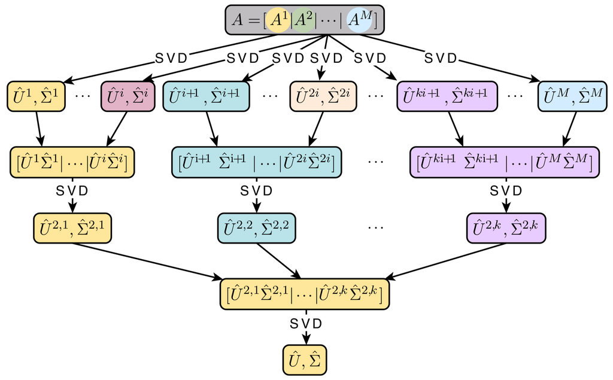

Figure 1: Flowchart for a two-level hierarchical Block SVD algorithm

This method is implemented in `bdSVD_hdf5` function, this function works directly on hdf5 data format, loading in memory only the data to perform calculations and saving the results again in the hdf5 file for later use.

We have to indicate the file to work with, the dataset name and the group under the dataset is located :

```r
# Direct from hdf5 data file
svdh5 <- bdSVD_hdf5("delayed.hdf5", "OMICS", "data")

 OLD Dataset have been REMOVED
svdh5$d[1:7]
NULL

# with R implementation from data in memory
fprova <- H5Fopen("delayed.hdf5")
omdata <- fprova$OMICS$data
h5closeAll()

svd <- svd(scale(omdata))
svd$d[1:7]
[1] 393.7274 393.3720 393.0192 392.6845 392.4629 391.7279 391.5869

all.equal(svd$d,svdh5$d )
[1] "Modes: numeric, NULL"               "Lengths: 50, 0"                     "target is numeric, current is NULL"
```

Like in Simple Singular Value Decomposition we can normalize, center or scale data before proceed with SVD decomposition with `bscale` and `bcenter` parameters, by default this parameter are TRUE, data is normalized before SVD decomposition. To proceed with SVD without normalization :

```r
# Direct from hdf5 data file
svdh5 <- bdSVD_hdf5("delayed.hdf5", "OMICS", "data",
                    bcenter = FALSE, bscale = FALSE)

 OLD Dataset have been REMOVED
svdh5$d[1:7]
NULL

# with R implementation from data in memory
svd <- svd(omdata)
svd$d[1:7]
[1] 393.8092 393.3840 393.1712 392.8305 392.7400 391.7171 391.6472

all.equal(svd$d,svdh5$d )
[1] "Modes: numeric, NULL"               "Lengths: 50, 0"                     "target is numeric, current is NULL"
```

In the SVD decomposition by blocks we can indicate the number of decomposition levels and number of local SVDs to concatenate at each level with parameters `q` and `k` respectively, by default `q = 1` one level with `k=2`.

```r
# Block decomposition with 1 level and 4 local SVDs at each level
svdh5 <- bdSVD_hdf5("delayed.hdf5", "OMICS", "data", q=1, k=4 )

 OLD Dataset have been REMOVED
svdh5$d[1:7]
NULL

# with R implementation from data in memory
svd <- svd(scale(omdata))
svd$d[1:7]
[1] 393.7274 393.3720 393.0192 392.6845 392.4629 391.7279 391.5869

all.equal(svd$d,svdh5$d )
[1] "Modes: numeric, NULL"               "Lengths: 50, 0"                     "target is numeric, current is NULL"
```

SVD decomposition with normalized data and different parameters executed in memmory and hdf5 files with functions from R base library and BigDataStatMeth library :

```r
bdSVD_hdf5_Normal_k2q1 <-
  "bdSVD_hdf5('delayed.hdf5',group='OMICS',dataset='data')"
bdSVD_hdf5_Normal_k4q1 <-
  "bdSVD_hdf5('delayed.hdf5',group='OMICS',dataset='data',k=4)"
bdSVD_hdf5_Normal_k4q2 <-
  "bdSVD_hdf5('delayed.hdf5',group='OMICS',dataset='data',q=2,k=4)"
bdSVD_memory_Normal <- 'bdSVD_lapack(omdata)'
svd_R_memory_Normal <- 'svd(scale(omdata))'

# With normalization process
# res <- microbenchmark( eval(parse(text=bdSVD_hdf5_Normal_k2q1)),
#                        eval(parse(text=bdSVD_hdf5_Normal_k4q1)),
#                        eval(parse(text=bdSVD_hdf5_Normal_k4q2)),
#                        eval(parse(text=bdSVD_memory_Normal)),
#                        eval(parse(text=svd_R_memory_Normal)),
#                        times = 3, unit = "s")
#
# print(summary(res)[, c(1:7)],digits=3)
```

SVD decomposition with not normalized data and different parameters executed in memmory and hdf5 files with functions from R base library and BigDataStatMeth library :

```r
# bdSVD_hdf5_NoNormal_k2q1 <-
#   "bdSVD_hdf5('delayed.hdf5',group='OMICS',dataset='data',bcenter=FALSE,bscale=FALSE)"
# bdSVD_hdf5_NoNormal_k4q1 <-
#   "bdSVD_hdf5('delayed.hdf5',group='OMICS',dataset='data',k=4,bcenter=FALSE,bscale=FALSE)"
# bdSVD_hdf5_NoNormal_k4q2 <-
#   "bdSVD_hdf5('delayed.hdf5',group='OMICS',dataset='data',q=2,k=4,bcenter=FALSE,bscale=FALSE)"
# bdSVD_memory_NoNormal <- 'bdSVD_lapack(omdata, bcenter = TRUE, bscale = TRUE)'
# svd_R_memory_NoNormal <- 'svd(omdata)'
#
# # Without normalization process
# res <- microbenchmark( eval(parse(text=bdSVD_hdf5_NoNormal_k2q1)),
#                        eval(parse(text=bdSVD_hdf5_NoNormal_k4q1)),
#                        eval(parse(text=bdSVD_hdf5_NoNormal_k4q2)),
#                        eval(parse(text=bdSVD_memory_NoNormal)),
#                        eval(parse(text=svd_R_memory_NoNormal)),
#                        times = 3, unit = "s")
#
# print(summary(res)[, c(1:7)],digits=3)
```

# 12 Using algebra procedure for `DelayedMatrix` objects to implement basic statistical methods

## 12.1 Principal component analysis (PCA)

Let us illustrate how to perform a PCA using miRNA data obtained from TCGA corresponding to 3 different tumors: melanoma (ME), leukemia (LEU) and centran nervous system (CNS). Data is available at `BigDataStatMeth` and can be loaded by simply:

```r
data(miRNA)
data(cancer)
dim(miRNA)
[1]  21 537
```

We observe that there are a total of 21 individuals and 537 miRNAs. The vector `cancer` contains the type of tumor of each individual. For each type we have:

```r
table(cancer)
cancer
CNS  LE  ME
  6   6   9
```

Now, the typical principal component analysis on the samples can be run on the `miRNA` matrix since it has miRNAs in columns and individuals in rows

```r
pc <- prcomp(miRNA)
```

We can plot the two first components with:

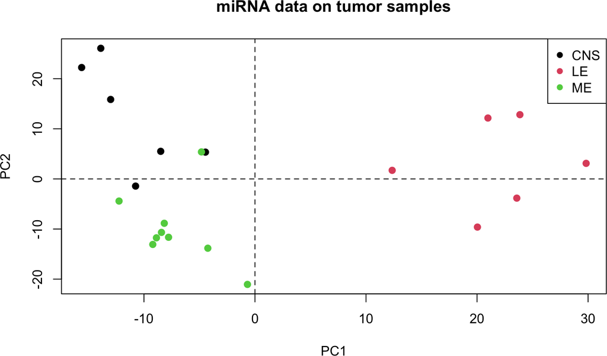

```r
plot(pc$x[, 1], pc$x[, 2],
     main = "miRNA data on tumor samples",
     xlab = "PC1", ylab = "PC2", type="n")
abline(h=0, v=0, lty=2)
points(pc$x[, 1], pc$x[, 2], col = cancer,
       pch=16, cex=1.2)
legend("topright", levels(cancer), pch=16, col=1:3)
```

```r
miRNAD <- DelayedArray(miRNA)
miRNAD.c <- DelayedArray::sweep(miRNAD, 2,
      DelayedArray::colMeans(miRNAD), "-")
svd.da <- bdSVD(miRNAD.c, bcenter = FALSE, bscale = FALSE)
```

The PCA plot for the two principal components can then be be obtained by:

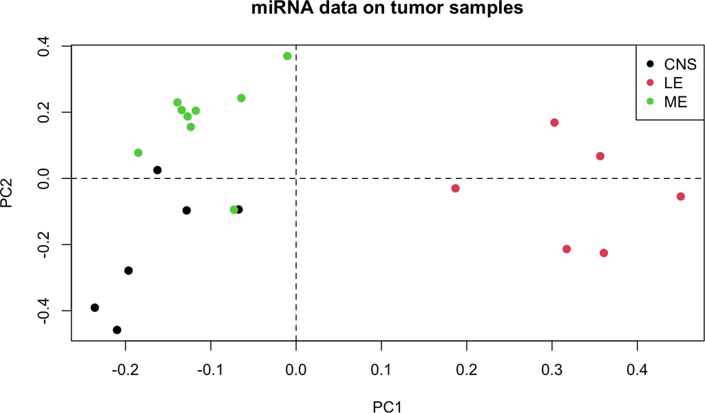

```r
plot(svd.da$u[, 1], svd.da$u[, 2],
     main = "miRNA data on tumor samples",
     xlab = "PC1", ylab = "PC2", type="n")
abline(h=0, v=0, lty=2)
points(svd.da$u[, 1], svd.da$u[, 2], col = cancer,
       pch=16, cex=1.2)
legend("topright", levels(cancer), pch=16, col=1:3)
```

We can observe that both figures are equal irrespective to a sign change of second component (that can happen in SVD).

# 13 References

[1] Fischer, Bernd, Gregoire Pau, and Mike Smith. (2019). R Interface to Hdf5. https://github.com/grimbough/rhdf5

# 14 Session information

```r
sessionInfo()
R version 4.0.5 RC (2021-03-27 r80128)
Platform: x86_64-apple-darwin17.0 (64-bit)
Running under: macOS Mojave 10.14.6

Matrix products: default
BLAS:   /Library/Frameworks/R.framework/Versions/4.0/Resources/lib/libRblas.dylib
LAPACK: /Library/Frameworks/R.framework/Versions/4.0/Resources/lib/libRlapack.dylib

locale:
[1] ca_ES.UTF-8/ca_ES.UTF-8/ca_ES.UTF-8/C/ca_ES.UTF-8/ca_ES.UTF-8

attached base packages:
[1] parallel  stats4    stats     graphics  grDevices utils     datasets  methods   base

other attached packages:
 [1] microbenchmark_1.4-7   DT_0.17                rhdf5_2.34.0           DelayedArray_0.16.2    IRanges_2.24.1         S4Vectors_0.28.1       MatrixGenerics_1.2.1
 [8] matrixStats_0.58.0     BiocGenerics_0.36.0    Matrix_1.3-2           BigDataStatMeth_0.99.1 knitr_1.31             BiocStyle_2.18.1

loaded via a namespace (and not attached):
 [1] Rcpp_1.0.6          lattice_0.20-41     assertthat_0.2.1    digest_0.6.27       utf8_1.2.1          R6_2.5.0            evaluate_0.14       highr_0.8
 [9] ggplot2_3.3.3       pillar_1.5.1        rlang_0.4.10        jquerylib_0.1.3     magick_2.7.1        rmarkdown_2.7       stringr_1.4.0       RcppEigen_0.3.3.9.1
[17] htmlwidgets_1.5.3   munsell_0.5.0       beachmat_2.6.4      compiler_4.0.5      xfun_0.22           pkgconfig_2.0.3     htmltools_0.5.1.1   tidyselect_1.1.0
[25] tibble_3.1.0        bookdown_0.21       codetools_0.2-18    fansi_0.4.2         crayon_1.4.1        dplyr_1.0.5         rhdf5filters_1.2.0  grid_4.0.5
[33] jsonlite_1.7.2      gtable_0.3.0        lifecycle_1.0.0     DBI_1.1.1           magrittr_2.0.1      scales_1.1.1        RcppParallel_5.0.3  stringi_1.5.3
[41] farver_2.1.0        bslib_0.2.4         ellipsis_0.3.1      vctrs_0.3.6         generics_0.1.0      Rhdf5lib_1.12.1     tools_4.0.5         glue_1.4.2
[49] purrr_0.3.4         yaml_2.2.1          colorspace_2.0-0    BiocManager_1.30.10 sass_0.3.1
```